# Single Cell Analysis

## Introduction

In this vignette, we will cover some of the possible sources for publicly available single-cell data, how to format it for and process it with MCIA and how to run a basic analysis in order to annotate the data and use the results as metadata for exploring the decomposition results.

[figure not shown]

Vignette 2 Pipeline

```r
# recommended location for local data
path_data <- file.path("..", "data")
```

## Data

We will be using the 10x Genomics “pbmc5k-CITEseq” dataset, which was published in May 2019 and processed using Cell Ranger 3.0.2. It contains 5,247 detected cells from PBMCs and 33,538 genes along with 32 cell surface markers. We chose this dataset due to it containing both gene expression (GEX) and cell surface protein (ADT) data as well as being relatively recent, publicly available and from a widely used platform.

The following code details several ways in which to load in this dataset. You may prefer to use data from other sources outside of 10x Genomics, in which case you will have to format it to work with nipalsMCIA.

### All Sources

```r
# marker genes for cell type annotation with Seurat
pb_download(file = "marker_genes.csv", dest = path_data,
            repo = "Muunraker/nipalsMCIA")

# the Seurat data's metric summary file from 10x Genomics
pb_download(file = "5k_pbmc_protein_v3_metrics_summary.csv", dest = path_data,
            repo = "Muunraker/nipalsMCIA")

# Seurat objects in different stages of processing
pb_download(file = "tenx_pbmc5k_CITEseq_raw.rds", dest = path_data,
            repo = "Muunraker/nipalsMCIA")
pb_download(file = "tenx_pbmc5k_CITEseq_annotated.rds", dest = path_data,
            repo = "Muunraker/nipalsMCIA")
```

### 10x Genomics and Seurat

The original dataset can be found on the [10x Genomics Datasets website](https://support.10xgenomics.com/single-cell-gene-expression/datasets/3.0.2/5k_pbmc_protein_v3) and an explanation of the file types for this version can be found [here](https://support.10xgenomics.com/single-cell-gene-expression/software/pipelines/3.0/output/overview). You can download them all to a directory of your choosing with their suggested terminal commands:

```r
# download the raw feature matrix
url = "https://cf.10xgenomics.com/samples/cell-exp/3.0.2/5k_pbmc_protein_v3/5k_pbmc_protein_v3_raw_feature_bc_matrix.tar.gz"
dest = file.path(path_data, "5k_pbmc_protein_v3_raw_feature_bc_matrix.tar.gz")
download.file(url,      destfile = dest, method = "auto")

# download the filtered feature matrix
url = "https://cf.10xgenomics.com/samples/cell-exp/3.0.2/5k_pbmc_protein_v3/5k_pbmc_protein_v3_filtered_feature_bc_matrix.tar.gz"
dest = file.path(path_data, "5k_pbmc_protein_v3_filtered_feature_bc_matrix.tar.gz")
download.file(url, destfile = dest, method = "auto")


# download the metrics summary
url = "https://cf.10xgenomics.com/samples/cell-exp/3.0.2/5k_pbmc_protein_v3/5k_pbmc_protein_v3_metrics_summary.csv"
dest = file.path(path_data, "5k_pbmc_protein_v3_metrics_summary.csv")
download.file(url, destfile = dest, method = "auto")


# download the summary html (optional)
url = "https://cf.10xgenomics.com/samples/cell-exp/3.0.2/5k_pbmc_protein_v3/5k_pbmc_protein_v3_web_summary.html"
dest = file.path(path_data, "5k_pbmc_protein_v3_web_summary.html")
download.file(url, destfile = dest, method = "auto")
```

If you would like to view some basic information about the data, you can open the *web_summary.html* in your favorite web browser. It will show the estimated number of cells, mean reads per cell, median genes per cell and a variety of other sample metrics. These metrics are also available in the *metrics_summary.csv* file.

You will need the *filtered_feature_bc_matrix* directory for the following analysis; it can be extracted with `tar -xvzf 5k_pbmc_protein_v3_filtered_feature_bc_matrix.tar.gz` from within the relevant data directory.

```r
tar_fn = file.path(path_data, "5k_pbmc_protein_v3_filtered_feature_bc_matrix.tar.gz")
#exdir = file.path(path_data, "5k_pbmc_protein_v3_filtered_feature_bc_matrix")
exdir = file.path(path_data, "tenx_pbmc5k_CITEseq")
untar(tar_fn, exdir = exdir, tar = "internal")
```

```r
# load the data (change the file path as needed)
data <- Seurat::Read10X(data.dir = file.path(path_data, "tenx_pbmc5k_CITEseq",
                                             "filtered_feature_bc_matrix"),
                        strip.suffix = TRUE) # remove the "-1"s from barcodes
```

```
## 10X data contains more than one type and is being returned as a list containing matrices of each type.
```

```r
## 10X data contains more than one type and is being returned as a list
## containing matrices of each type.

# set minimum cells and/or features here if you'd like
obj <- Seurat::CreateSeuratObject(counts = data$`Gene Expression`,
                                  project = "pbmc5k_CITEseq")
obj[["ADT"]] <- Seurat::CreateAssayObject(counts = data$`Antibody Capture`)
## Warning: Feature names cannot have underscores ('_'), replacing with dashes ('-')

# check the assays
Seurat::Assays(object = obj)
```

```
## [1] "RNA" "ADT"
```

```r
## "RNA" "ADT"

# list out the CITE-Seq surface protein markers
rownames(obj[["ADT"]])
```

```
##  [1] "CD3-TotalSeqB"           "CD4-TotalSeqB"
##  [3] "CD8a-TotalSeqB"          "CD11b-TotalSeqB"
##  [5] "CD14-TotalSeqB"          "CD15-TotalSeqB"
##  [7] "CD16-TotalSeqB"          "CD19-TotalSeqB"
##  [9] "CD20-TotalSeqB"          "CD25-TotalSeqB"
## [11] "CD27-TotalSeqB"          "CD28-TotalSeqB"
## [13] "CD34-TotalSeqB"          "CD45RA-TotalSeqB"
## [15] "CD45RO-TotalSeqB"        "CD56-TotalSeqB"
## [17] "CD62L-TotalSeqB"         "CD69-TotalSeqB"
## [19] "CD80-TotalSeqB"          "CD86-TotalSeqB"
## [21] "CD127-TotalSeqB"         "CD137-TotalSeqB"
## [23] "CD197-TotalSeqB"         "CD274-TotalSeqB"
## [25] "CD278-TotalSeqB"         "CD335-TotalSeqB"
## [27] "PD-1-TotalSeqB"          "HLA-DR-TotalSeqB"
## [29] "TIGIT-TotalSeqB"         "IgG1-control-TotalSeqB"
## [31] "IgG2a-control-TotalSeqB" "IgG2b-control-TotalSeqB"
```

## Deep dive: Seurat analysis

This section demonstrates how to take in raw data (in this case, the output of Cell Ranger v3.0) and go through a popular analysis pipeline to ultimately cluster and annotate the data. Some people prefer to use Cell Ranger’s built-in dimension reduction and clustering analysis and to view the results with [Loupe Cell Browser](https://support.10xgenomics.com/single-cell-gene-expression/software/visualization/latest/what-is-loupe-cell-browser).

*Credit to Seurat ([RNA](https://satijalab.org/seurat/articles/pbmc3k_tutorial.html) and [multi-modal](https://satijalab.org/seurat/articles/multimodal_vignette.html#setup-a-seurat-object-add-the-rna-and-protein-data)) for the general steps.*

### Read in and process the data

```r
# load the data

# add useful metadata
obj[["percent.mt"]] <- PercentageFeatureSet(object = obj, pattern = "^MT-")
```

### Quality control

#### Metrics summary

```r
# read in the summary table
(metrics_summary <- read.csv(
    file = file.path(path_data, "5k_pbmc_protein_v3_metrics_summary.csv")
))
```

| Estimated.Number.of.Cells | Mean.Reads.per.Cell | Median.Genes.per.Cell | Number.of.Reads | Valid.Barcodes | Sequencing.Saturation | Q30.Bases.in.Barcode | Q30.Bases.in.RNA.Read | Q30.Bases.in.Sample.Index | Q30.Bases.in.UMI | Reads.Mapped.to.Genome | Reads.Mapped.Confidently.to.Genome | Reads.Mapped.Confidently.to.Intergenic.Regions | Reads.Mapped.Confidently.to.Intronic.Regions | Reads.Mapped.Confidently.to.Exonic.Regions | Reads.Mapped.Confidently.to.Transcriptome | Reads.Mapped.Antisense.to.Gene | Fraction.Reads.in.Cells | Total.Genes.Detected | Median.UMI.Counts.per.Cell | Antibody..Number.of.Reads | Antibody..Mean.Reads.per.Cell | Antibody..Valid.Barcodes | Antibody..Sequencing.Saturation | Antibody..Q30.Bases.in.Barcode | Antibody..Q30.Bases.in.Antibody.Read | Antibody..Q30.Bases.in.Sample.Index | Antibody..Q30.Bases.in.UMI | Antibody..Fraction.Antibody.Reads | Antibody..Fraction.Antibody.Reads.Usable | … |
| --- | --- | --- | --- | --- | --- | --- | --- | --- | --- | --- | --- | --- | --- | --- | --- | --- | --- | --- | --- | --- | --- | --- | --- | --- | --- | --- | --- | --- | --- | --- |
| 5,247 | 28,917 | 1,646 | 151,731,342 | 97.5% | 52.4% | 95.8% | 91.9% | 89.8% | 95.4% | 94.3% | 88.4% | 6.8% | 25.0% | 56.7% | 53.2% | 1.3% | 87.7% | 20,840 | 5,506 | 39,096,673 | 7,451 | 99.0% | 39.6% | 96.7% | 96.0% | 87.5% | 96.8% | 94.3% | 67.4% | … |

#### GEX QC metrics

##### Before filtering

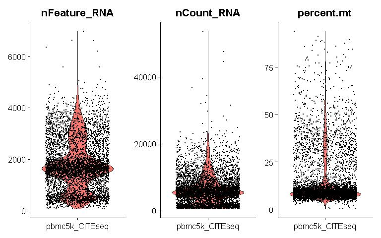

```r
VlnPlot(object = obj,
        features = c("nFeature_RNA", "nCount_RNA", "percent.mt"),
        pt.size = 0.01, ncol = 3) &
  theme(axis.text.x = element_text(angle = 0, hjust = 0.5),
        axis.title.x = element_blank())
```

##### After filtering

Based on the previous plots, a minimum of 200 features and a maximum of 20% mitochondrial seemed like good cutoffs.

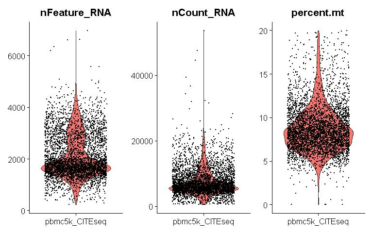

```r
# adjust cutoffs as desired
obj <- subset(x = obj, subset = nFeature_RNA > 200 & percent.mt < 20)

VlnPlot(object = obj,
        features = c("nFeature_RNA", "nCount_RNA", "percent.mt"),
        pt.size = 0.01, ncol = 3) &
  theme(axis.text.x = element_text(angle = 0, hjust = 0.5),
        axis.title.x = element_blank())
```

### Standard Seurat pipeline

**Most of these are run on the RNA**.

```r
# standard log normalization for RNA and centered log for ADT
obj <- NormalizeData(object = obj, normalization.method = "LogNormalize",
                     scale.factor = 10000, assay = "RNA")
```

```r
obj <- NormalizeData(object = obj, normalization.method = "CLR",
                     margin = 2, assay = "ADT") # go across cells, not
```

```
## Normalizing across cells
```

```r
# highly variable features
obj <- FindVariableFeatures(object = obj, selection.method = "vst",
                            nfeatures = 2000)
```

```r
# scaling so the average expression is 0 and the variance is 1
obj <- ScaleData(object = obj, features = rownames(obj))
# dimensionality reduction
obj <- RunPCA(object = obj)
```

```
## PC_ 1
## Positive:  LYZ, FCN1, CST3, MNDA, CTSS, PSAP, S100A9, FGL2, AIF1, GRN
##     NCF2, LST1, CD68, TYMP, SERPINA1, CYBB, CLEC12A, CSTA, SPI1, TNFAIP2
##     CPVL, VCAN, MPEG1, TYROBP, KLF4, FTL, S100A8, IGSF6, CD14, MS4A6A
## Negative:  CD3D, TRAC, LTB, TRBC2, IL32, CD3G, IL7R, CD69, CD247, TRBC1
##     CD2, CD7, CD27, ARL4C, ISG20, HIST1H4C, SYNE2, GZMM, ITM2A, CCR7
##     RORA, MAL, CXCR4, LEF1, TRAT1, CTSW, GZMA, KLRB1, TRABD2A, CCL5
## PC_ 2
## Positive:  CD79A, MS4A1, IGHM, BANK1, HLA-DQA1, CD79B, IGKC, LINC00926, RALGPS2, TNFRSF13C
##     VPREB3, IGHD, SPIB, CD22, FCRL1, HLA-DQB1, BLK, FAM129C, FCRLA, TCL1A
##     GNG7, TCF4, COBLL1, PAX5, SWAP70, CD40, BCL11A, P2RX5, TSPAN13, ADAM28
## Negative:  NKG7, CST7, GZMA, PRF1, KLRD1, CTSW, FGFBP2, GNLY, GZMH, CCL5
##     GZMM, CD247, KLRF1, HOPX, SPON2, ADGRG1, TRDC, MATK, GZMB, FCGR3A
##     S100A4, CCL4, CLIC3, KLRB1, IL2RB, TBX21, TTC38, ANXA1, PTGDR, PLEKHF1
## PC_ 3
## Positive:  GZMB, NKG7, GNLY, CLIC3, PRF1, KLRD1, FGFBP2, KLRF1, SPON2, CST7
##     GZMH, FCGR3A, ADGRG1, GZMA, HOPX, CTSW, TRDC, CCL4, HLA-DPB1, C12orf75
##     PLAC8, TTC38, PLEK, APOBEC3G, TBX21, PRSS23, CYBA, MATK, SYNGR1, CXXC5
## Negative:  IL7R, MAL, LEF1, TRABD2A, TRAC, CCR7, LTB, CD27, FOS, LRRN3
##     FHIT, TRAT1, RGCC, CAMK4, CD3D, RGS10, CD40LG, FOSB, AQP3, SOCS3
##     FLT3LG, CD3G, SLC2A3, TSHZ2, VIM, S100A12, S100A8, CD28, PLK3, VCAN
## PC_ 4
## Positive:  FCER1A, PLD4, SERPINF1, IL3RA, CLEC10A, GAS6, LILRA4, TPM2, CLEC4C, ENHO
##     FLT3, SMPD3, ITM2C, LGMN, CD1C, P2RY14, PPP1R14B, SCT, PROC, LAMP5
##     RUNX2, AC119428.2, PACSIN1, DNASE1L3, PTCRA, RGS10, UGCG, CLIC2, PPM1J, P2RY6
## Negative:  MS4A1, CD79A, LINC00926, BANK1, TNFRSF13C, VPREB3, CD79B, RALGPS2, IGHD, FCRL1
##     BLK, IGHM, CD22, PAX5, ARHGAP24, CD24, P2RX5, NCF1, S100A12, CD19
##     SWAP70, FCRLA, VNN2, TNFRSF13B, FCER2, IGKC, FCRL2, RBP7, CD40, S100A8
## PC_ 5
## Positive:  BATF3, C1QA, TCF7L2, CTSL, CDKN1C, HLA-DQB1, HES4, SIGLEC10, CLEC10A, ABI3
##     HLA-DQA1, RHOC, CSF1R, ENHO, CAMK1, MTSS1, IFITM3, CD1C, LY6E, FCGR3A
##     HLA-DPA1, CLIC2, HLA-DPB1, YBX1, RRAS, AC064805.1, NR4A1, GBP1, ZNF703, CXCL16
## Negative:  LILRA4, TPM2, CLEC4C, SMPD3, IL3RA, SERPINF1, DERL3, MZB1, SCT, JCHAIN
##     PACSIN1, PROC, S100A12, PTCRA, LINC00996, PADI4, ASIP, KCNK17, ITM2C, EPHB1
##     ALOX5AP, LAMP5, DNASE1L3, MAP1A, S100A8, APP, CYP1B1, VNN2, UGCG, ZFAT
```

```r
# clustering (adjust dimensions and resolutions as desired)
obj <- FindNeighbors(object = obj, reduction = "pca", dims = 1:20)
obj <- FindClusters(object = obj, resolution = 0.4)
```

```
## Modularity Optimizer version 1.3.0 by Ludo Waltman and Nees Jan van Eck
##
## Number of nodes: 4193
## Number of edges: 154360
##
## Running Louvain algorithm...
## Maximum modularity in 10 random starts: 0.9097
## Number of communities: 10
## Elapsed time: 0 seconds
```

```r
obj <- RunUMAP(object = obj, reduction = "pca", dims = 1:20)
```

### Dimensionality reduction

#### Load in the processed object

To avoid having to save multiple large objects, this file already includes the annotations defined in a later section, so we will clear them out here to proceed as normal.

```r
# reset to baseline
Idents(object = obj) <- "seurat_clusters"
#obj$annotated_clusters <- c()
```

#### PCA

**Typically this section would go in between the `RunPCA()` and `FindNeighbors()` steps above**. It has been included here because of how we save and load the objects separately for processing speed.

Now that we’ve run PCA, we can examine an elbow plot as a simple method for selecting how many PCs to choose when identifying neighbors/clusters.

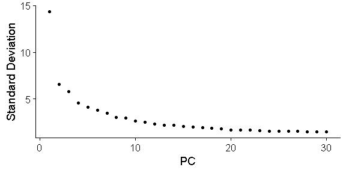

```r
ElbowPlot(object = obj, ndims = 30)
```

From the plot, it looked like 20 works as a cut-off for the number of PCs to include. We could have also chosen to use 10, but decided to go a little higher.

You can also examine other information which was used for the PCA, such as the top twenty most variable features:

```r
head(VariableFeatures(object = obj), 20)
```

```
##  [1] "IGLC2"    "IGLC3"    "HLA-DQA1" "FCER1A"   "C1QA"     "PTGDS"
##  [7] "GNLY"     "CLEC10A"  "IGHM"     "IGKC"     "CCL4L2"   "JCHAIN"
## [13] "LYPD2"    "CD1C"     "CCL4"     "C1QB"     "HLA-DPA1" "HLA-DPB1"
## [19] "EREG"     "HLA-DRB1"
```

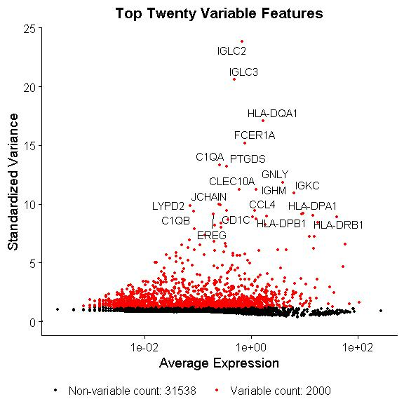

```r
# these can be plotted if desired
LabelPoints(plot = VariableFeaturePlot(object = obj),
            points = head(VariableFeatures(object = obj), 20),
            repel = TRUE, xnudge = 0, ynudge = 0) +
  labs(title = "Top Twenty Variable Features") +
  theme(legend.position = "bottom")
```

#### UMAP

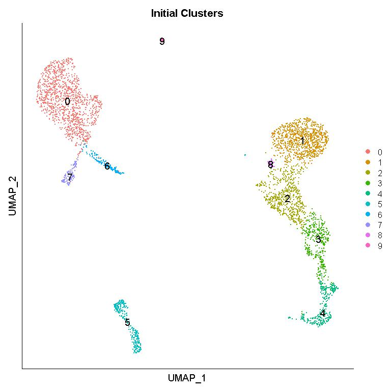

```r
# you can also use the LabelClusters function to help label individual clusters
plot_seurat_clusters <- UMAPPlot(object = obj, label = TRUE, label.size = 5) +
                          labs(title = "Initial Clusters") +
                          theme(plot.title = element_text(hjust = 0.5),
                                axis.text = element_blank(),
                                axis.ticks = element_blank())
plot_seurat_clusters
```

### Marker overlays

Note that the following marker genes **are not meant to be an exhaustive list.** They are included as examples of some of the cell types you could look for.

#### Load marker genes

```r
# sort by Cell_Type and Marker if not already sorted
markers_all <- read.csv(file = file.path(path_data, "marker_genes.csv"))
markers_all %>% slice_sample(n = 10) # example markers
```

| Cell_Type | Marker |
| --- | --- |
| Macrophages | CD68 |
| T | CAMK4 |
| pDC | LILRA4 |
| Plasma | JCHAIN |
| mDC | FCER1A |
| T | CD3E |
| Plasma | TRIB1 |
| B | IGHM |
| NK | NKG7 |
| Plasma | SDC1 |

#### Dot plots

##### GEX

Here we only demonstrate a few of the cell types included within the provided markers database. We plot those cell types on top of the dot plot to make it easier to see which markers they correspond with, but you can comment that code out if you would rather have a simple dot plot.

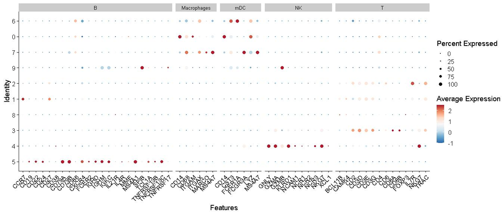

```r
select_cell_types <- c("B", "Macrophages", "mDC", "NK", "T")

# do features = unique(markers_all$Marker) to use all possible features
p <- DotPlot(object = obj,
             features = markers_all %>%
                          dplyr::filter(Cell_Type %in% select_cell_types) %>%
                          distinct(Marker) %>% pull(),
             cols = "RdBu", col.min = -1, dot.scale = 3, cluster.idents = TRUE)

# add in the cell type information
# if desired, you could rename the "Cell_Type"s in the original database to be
# more informative e.g. Natural_Killers instead of NK
p$data <- left_join(p$data,
                    markers_all %>%
                      dplyr::filter(Cell_Type %in% select_cell_types) %>%
                      dplyr::rename(features.plot = "Marker"),
                    by = "features.plot", multiple = "all")

# plot
p +
  facet_grid(cols = vars(Cell_Type), scales = "free_x", space = "free") +
  theme(strip.text.x = element_text(size = 10)) + RotatedAxis()
```

##### ADT

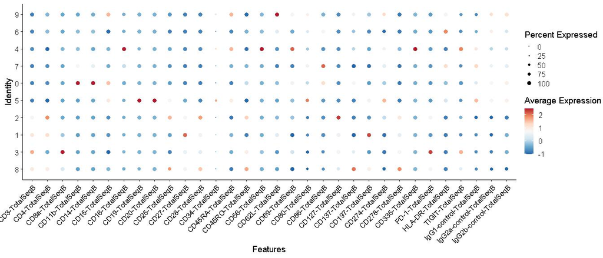

```r
# you have to change the default assay for the dot plot
DefaultAssay(object = obj) <- "ADT"

DotPlot(object = obj,
        features = rownames(GetAssayData(object = obj, assay = "ADT",
                                         slot = "counts")),
        cols = "RdBu", col.min = -1, dot.scale = 3, cluster.idents = TRUE) +
  RotatedAxis()
```

```r
# reset the default
DefaultAssay(object = obj) <- "RNA"
```

#### Feature plots

If you would like to generate feature plots for a cell type within your markers database (if you are using one) e.g. for B cells, you could do `features = (dplyr::filter(markers_all, Cell_Type == "B"))$Marker` in the following command. Here we just show a few characteristic markers for different cell types for simplicity.

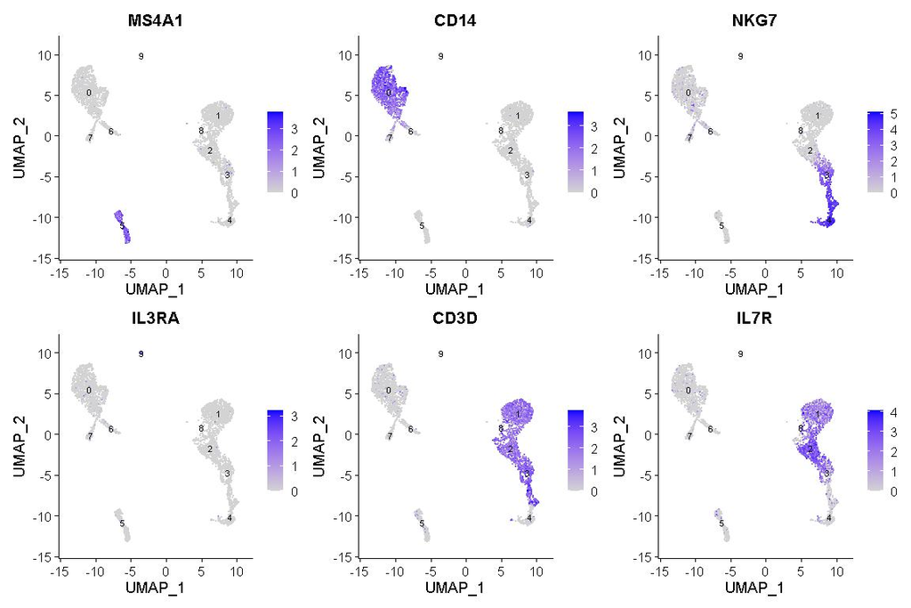

```r
FeaturePlot(object = obj,
            features = c("MS4A1", "CD14", # MS4A1 is another name for CD20
                         "NKG7", "IL3RA", "CD3D", "IL7R"),
            min.cutoff = 0, label = TRUE, label.size = 3,
            ncol = 3, raster = FALSE)
```

#### Violin plots

Here the point size is set to zero so that you can just see the violins. We only show a few of the cell surface markers here, but you could plot them all with `features = rownames(obj[["ADT"]])`. You can also plot the standard GEX markers just like for the feature plots (just make sure to remove `assay = "ADT"`).

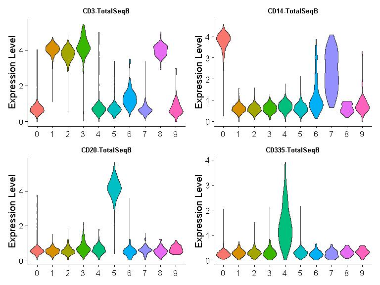

```r
VlnPlot(object = obj,
        features = c("CD3-TotalSeqB", "CD14-TotalSeqB", "CD20-TotalSeqB",
                     "CD335-TotalSeqB"),
        pt.size = 0, assay = "ADT", ncol = 2) &
  theme(plot.title = element_text(size = 10),
        axis.text.x = element_text(angle = 0, hjust = 0.5),
        axis.title.x = element_blank())
```

### Annotate cell clusters

These annotations are chosen here more as a proof of general concept instead of a more highly refined and verified approach that you would typically see within a single-cell publication. There are also [automated methods for annotation](https://www.sciencedirect.com/science/article/pii/S2001037021000192).

#### Annotations

If you would like to further break down these clusters, you can increase the clustering resolution in the standard pipeline in order to increase the number of clusters.

```r
# mDC = myeloid dendritic cells
# pDC = plasmacytoid dendritic cells
obj_annotations <- rbind(c("0", "Macrophages/mDCs"), # difficult to separate
                         c("1", "T Cells"),
                         c("2", "T Cells"),
                         c("3", "T Cells"),
                         c("4", "Natural Killers"),
                         c("5", "B Cells"),
                         c("6", "Macrophages/mDCs"), # difficult to separate
                         c("7", "Macrophages/mDCs"), # difficult to separate
                         c("8", "T Cells"), # faint signal
                         c("9", "pDCs"))
colnames(obj_annotations) <- c("Cluster", "CellType")
obj_annotations <- data.frame(obj_annotations)

# save the annotations as a csv if you'd like
# write.csv(obj_annotations, file = file.path(path_data, "obj_annotations.csv"))

# prepare the annotation information
annotations <- setNames(obj_annotations$CellType, obj_annotations$Cluster)

# relabel the Seurat clusters
# Idents(obj) <- "seurat_clusters"
obj <- RenameIdents(object = obj, annotations)

# alphabetize the cell types
Idents(obj) <- factor(Idents(object = obj), levels = sort(levels(obj)))

# useful metadata (e.g. if you want to have multiple annotation sets)
obj[["annotated_clusters"]] <- Idents(object = obj)

# save the processed and annotated Seurat object
# saveRDS(obj, file = file.path(path_data, "tenx_pbmc5k_CITEseq_annotated.rds"))

# info about the clusters
obj_annotations %>%
  group_by(CellType) %>%
  transmute(Clusters = paste0(Cluster, collapse = ", ")) %>%
  distinct() %>%
  arrange(CellType)
```

| CellType | Clusters |
| --- | --- |
| B Cells | 5 |
| Macrophages/mDCs | 0, 6, 7 |
| Natural Killers | 4 |
| T Cells | 1, 2, 3, 8 |
| pDCs | 9 |

```r
# metadata file for MCIA
meta <- data.frame("CellType" = Idents(object = obj))

# save the metadata file for MCIA
# write.csv(meta, file = file.path(path_data, "metadata_sc.csv"))
```

#### UMAPs

```r
# change colors and themes as desired
# plot_annotated_clusters <- UMAPPlot(object = obj,
#                                     label = TRUE, label.size = 4,
#                                     cols = meta_colors_sc) +
#                              labs(title = "Annotated Clusters") +
#                              theme(plot.title = element_text(hjust = 0.5),
#                                    axis.text = element_blank(),
#                                    axis.ticks = element_blank())
#
# ggarrange(plot_seurat_clusters, plot_annotated_clusters)
```

You should change the `DefaultAssay` to/from `ADT` like in ADT if you don’t want to specify “adt_” before the feature name.

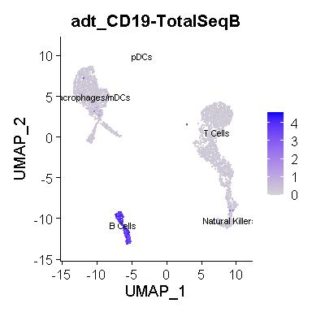

```r
# plot ADT information on top as an example

FeaturePlot(object = obj, features = "adt_CD19-TotalSeqB",
            label = TRUE, label.size = 3, ncol = 1, raster = FALSE)
```

#### Check the annotations

For example, if you want to visually check your T cell cluster annotations (just like before, you can also do `features = (dplyr::filter(markers_all, Cell_Type == "T"))$Marker` to use all of the T cell markers in the markers database):

```r
# VlnPlot(object = obj,
#         features = c("CD3D", "CD4", "IL7R", "TRAC"),
#         cols = meta_colors_sc, pt.size = 0.01, ncol = 2) &
#   theme(plot.title = element_text(size = 10),
#         axis.title.x = element_blank())
```